# PHRM7021: Introductory Tutorial

Adam La Caze

Semester 1, 2023

## Agenda

1. Course aims and objectives
2. Course design principles
3. Course components and assessment
4. Group work
5. Tips
6. Questions?

## Contact

Adam La Caze

E: a.lacaze@uq.edu.au  
W: https://researchers.uq.edu.au/researcher/1112

## Course discussion

- [Ed Discussion Board](https://edstem.org/au/courses/10685/discussion/) for course-level discussion and questions
- Microsoft Teams for group discussion and collaboration: tutorials, module activities

## Course aims

- This course is designed to provide clinical pharmacists with skills in appraising and designing research and practice improvement studies.
- The course provides practical opportunities for students to develop their research skills. Students have the opportunity to conduct and analyse a small qualitative research study, develop skills in quantitative data analysis, develop research and evaluation questions, pitch project ideas and to develop a project proposal.

## PHRM7095

- You complete a structured project in clinical pharmacy practice.
- The project can be a research project, quality improvement project or practice change project and should seek to improve some aspect of patient care or patient outcomes.

See [here](https://alacaze.net/teaching/phrm7021/projectapproval/) for more details.

## Some lessons from PHRM7095

1. You can complete research or evaluation (or other types of project)
2. Think local; ensure feasibility
3. If you need to collect data, you should aim to be able to collect within 4 weeks
4. Think about ethics and other approvals early

## Course outline

- **Module 1** Developing Research and Evaluation Questions
- **Module 2** Principles of Qualitative and Quantitative Analysis
- **Module 3** Writing a Project Proposal

## Course design principles

- Tight links between learning activities, assessment and learning outcomes
- Progressively build your skills and knowledge through the semester
- Foster active collaborative learning
- Develop and demonstrate skills and knowledge that you can apply in practice

## Course objectives

1. Critically appraise and synthesise current evidence in a particular context
2. Identify a gap in practice or knowledge that can be addressed through research and evaluation
3. Develop focused, feasible, answerable research and evaluation questions
4. Demonstrate an understanding of the principles of quantitative and qualitative data analysis
5. Collect and analyse qualitative or quantitative data while ensuring the rigour and quality of that data
6. Develop a project proposal in the area of pharmacy practice covering study design, methodology, data analysis and ethical considerations
7. Communicate research ideas and project plans to a knowledgeable, non-expert audience

## Course components

- Module participation (blogs and quizzes) Formative
- Module activities (“Green Discussion Board”)
- Tutorial activities (Blue Discussion Board): with Peer Group Assessment
- Assignments: Project Outline, Analysis Assignment, Project Proposal

## Assessment

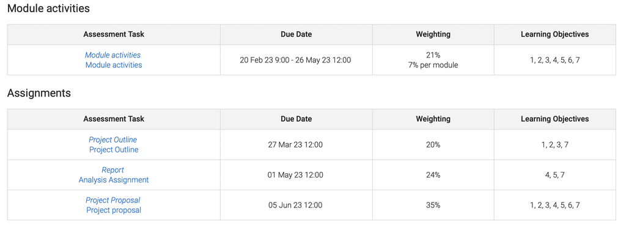

## Calendar

[Course Google Calendar](https://calendar.google.com/calendar/embed?src=66eljg3edhshna6rgjch6kbcno%40group.calendar.google.com&ctz=Australia%2FBrisbane)

## Group Work

- Group work is an important part of PHRM7021
- [Resources](https://my.uq.edu.au/information-and-services/student-support/study-skills/group-work/forming-group) for forming and working well as a group

Spend some time *forming* the group

Agree on some general principles for the group

Recognise the variety of roles needed (and try to share these roles around throughout the course)

## Group work suggestions for PHRM7021

- *Read* the group task within the first week of the module
- *Contribute* to the group task by the second week of the module
- Contribute to each task—regardless of whether you are presenting or commenting
- Communicate to your group if your contribution is going to be delayed (or if there is a period of time you are unavailable)
- Share leadership; show leadership when you are presenting/commenting

## Peer Group Marking (for Tutorial tasks)

- Compulsory part of activity
- Rate each of your group members contributions to the tutorial.
- Distribute 100 points to each of the team members including yourself
- Justify your allocation
- Group weighting will provide *peer assessment factor* to moderate individual marks

## Tips

- [Searching for fulltext papers via Google Scholar](https://web.library.uq.edu.au/research-tools-techniques/google-scholar)
- [Digital Essentials](https://web.library.uq.edu.au/research-tools-techniques/digital-essentials)
- Undertaking the quantitative component requires a commitment to learning the basics of R (or alternative statistical software)